# Probability and Data - BFRSS Data

### Overview and Population

The Behavioral Risk Factor Surveillance System (BFRSS) is an ongoing survey designed to measure risk factors in the United States. The population of the survey is non-institutionalized adult population a (18+) that resides in the United States.

### Method of Collection

Fifty-one of the State projects used a Disproportionate Stratified Sample (DSS) design for the landline samples. Guam and Puerto Rico use a simple random sample design. For landline phone sampling, numbers are divided into two strata and then samples are taken from each strata.

For cellular phones the BRFSS uses a commercial system that calls random samples of cellular telephone numbers. Furthermore, the commercial system uses an interval type of system to ensure random sampling from the population.

### Causality or Generalizability

This is an observational study that uses random sampling as explained above. Therefore, proper analysis with the data is generalizable to the population, but cannot be used for causal analysis.

### Load Data and Libraries

Begin by loading the the libraries and a version of `brfss2013` that contains only the needed variables for this analysis.

```r
library(dplyr)
library(ggplot2)
load(file="brfss_slice.RData")
```

### Create 3 new variables needed for analysis

The three variable below will be created and used in the analysis. The output shows all the variable names in the data used for analysis.

```r
## Degree or No Degree
brfss_slice <- brfss_slice %>%
  mutate(collegegrad = ifelse(as.numeric(edulvl) == 4, "degree", "nodegree"))
## Homeowner or other
brfss_slice <- brfss_slice %>%
  mutate(ishomeowner = ifelse(as.numeric(renthome) == 1, "homeowner", "other"))
##Over eight hours sleep
brfss_slice <- brfss_slice %>%
mutate(enoughsleep = ifelse(sleptim1 >= 8, "over", "under"))

names(brfss_slice)
```

```
##  [1] "gender"      "age"         "celluse"     "edulvl"      "renthome"
##  [6] "sleptim1"    "X_bmi5"      "enoughsleep" "collegegrad" "ishomeowner"
```

### Research Question #1

**Is there a difference in the amount of cell phone use between gender or age?**

**Variables Used:**

1. age (age of respondent 18-80)
2. sex (gender of respondent male or female)
3. cpdemo4 (Percent of calls received on cell phone)

**Summary Stats:**

The calculated average cell phone use of the population is 41%.

**Description:** This code creates a bar plot that visualizes average cell phone use by gender.

**Outcome analysis:** This is a simple visual that shows men have higher average cell phone use then women. Women are also below the population mean of 40.66 and men are above the population mean.

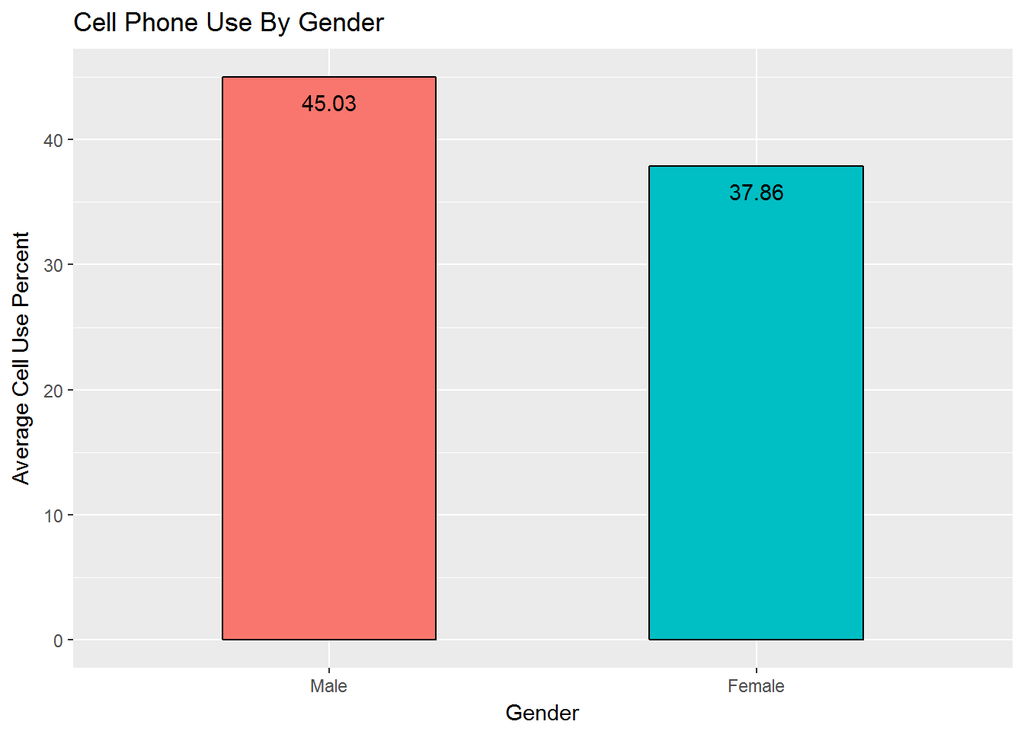

```r
brfss_slice %>% group_by(gender) %>%
  summarise(cell_mean = mean(celluse)) %>%

ggplot(aes(x=gender, y = cell_mean, fill = gender,width = .5)) +
  geom_bar(stat = "identity", colour="black") +
  guides(fill=FALSE) +
  labs(x = "Gender", y = "Average Cell Use Percent", title = "Cell Phone Use By Gender") +
    geom_text(aes(label=round(cell_mean,2), vjust=2))
```

```r
##Mean of Population
round(mean(brfss_slice$celluse)/100,2)*100
```

```
## [1] 41
```

```r
##Standard Deviation of Population
round(sd(brfss_slice$celluse)/100,2)*100
```

```
## [1] 35
```

**Cell Phone Use by Age:**

**Description:** The code below creates a line plot that shows average cell phone usage by age.

**Outcome analysis:** This is an interesting visual as it shows the dramatic dropoff of cell usage from young to old. It would be interesting to run this analysis again in 20 years to see how much cell phone use increased in the older population.

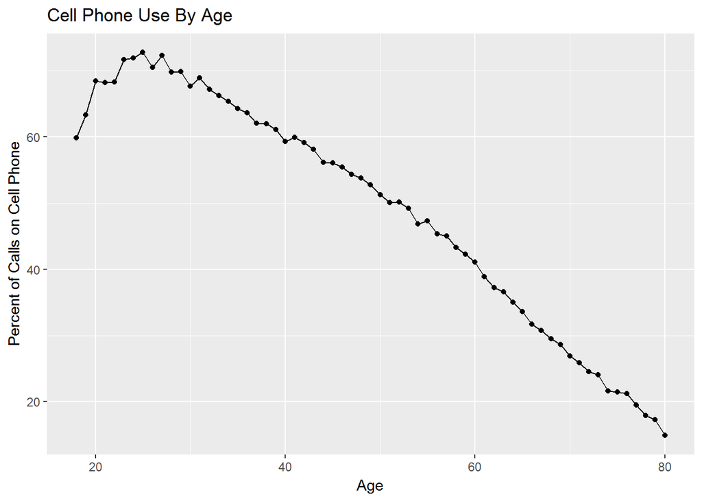

```r
brfss_slice %>%
  select(age, celluse) %>%
  filter(!is.na(age)) %>%
  filter(age >= 18) %>%
    group_by(age) %>%
    summarise(cell_mean = mean(celluse)) %>%

  ggplot(aes(x=age, y=cell_mean)) +
  geom_line() +
  geom_point() +
  labs(x = "Age", y = "Percent of Calls on Cell Phone", title = "Cell Phone Use By Age")
```

### Research Question #2

**Are you more likely to own a home if you graduated college?**

**Variables Used:**

1. _educag (Level of Education completed)
2. collegegrad (Created variable - graduated college)
3. renthom1 (do you own or rent your home or other arrangement)
4. ishomeowner (Created variable for home ownership)

**Summary Stats:**

There are no relevant summary stats for this analysis as it uses the count of the distributions.

**Description:** The code below creates a stacked bar plot to show the proportion of home ownership between those with a college degree and those with no degree.

**Outcome:** The bar graph shows that home ownership is higher for those who have a college degree.

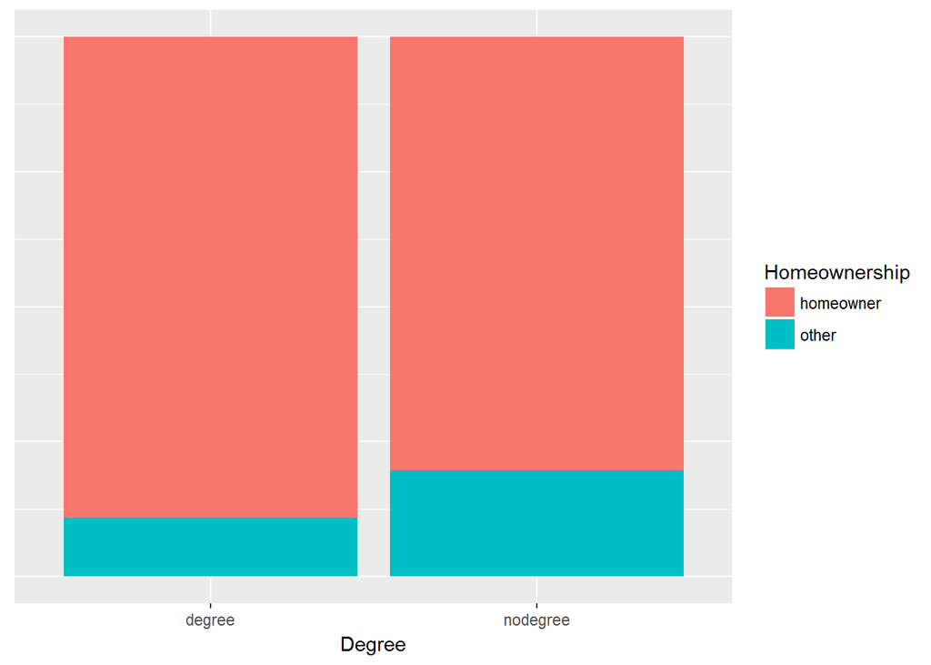

```r
df <- data.frame(table(brfss_slice$collegegrad,brfss_slice$ishomeowner))
 names(df) <- c("Degree", "Homeownership", "Count")

ggplot(data=df, aes(x=Degree, y=Count, fill=Homeownership)) +
  geom_bar(stat="identity", position = "fill") +
  theme(axis.text.y = element_blank(),
        axis.ticks.y = element_blank(),
        axis.title.y = element_blank())
```

### Research Question #3

**Do people who sleep 8 hours or more have a healthier average BMI then those who sleep less than 8 hours?**

**Variables Used:**

1. sleptim1 (how many hours slept in 24 hour period on average)
2. _bmi5 (computed body mass index - BMI)

**Summary Stats:** The calculated mean BMI for the poulation is **27.88** with a Standard Deviation of **5.98**.

**Description:** The code below creates a side by side bar plot measuring the average bmi for those who get over 8 hours of sleep and those who sleep under 8 hours on average.

**Outcome:** The graph shows that there is little difference in the averages between the two groups.

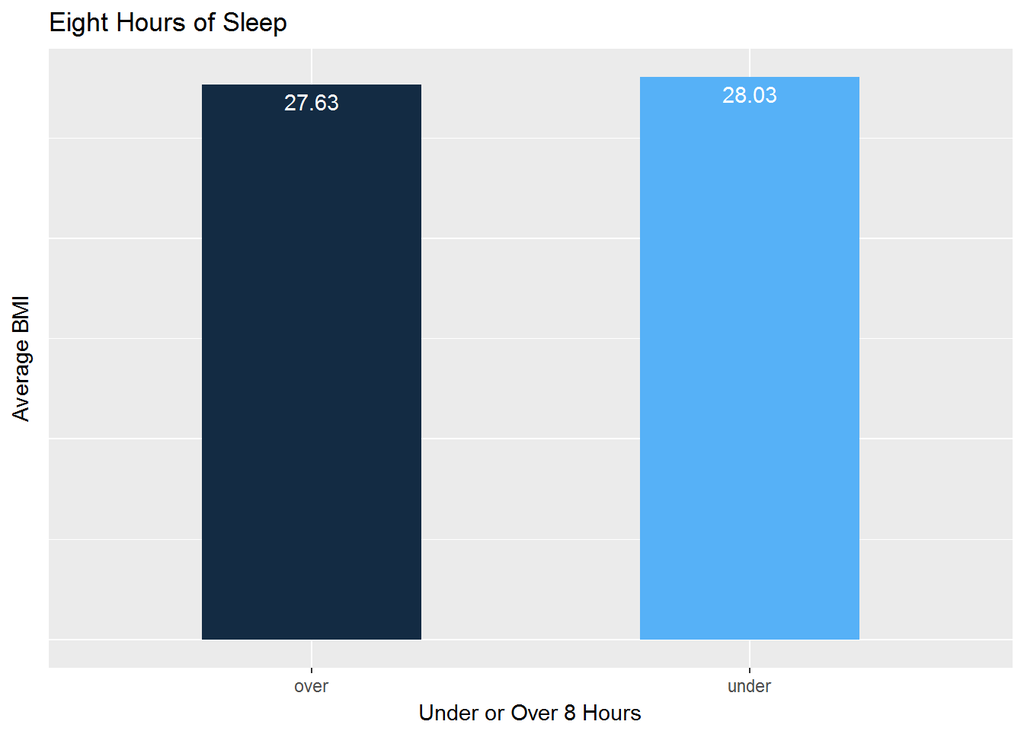

```r
brfss_slice  %>%
  group_by(enoughsleep) %>%
summarise(bmi_mean = mean(X_bmi5)) %>%

ggplot(aes(x=enoughsleep, y = bmi_mean, fill = bmi_mean, width = .5 )) +
  geom_bar(stat="identity") +
    geom_text(aes(label= round(bmi_mean/100, 2)), vjust=1.5, color='white')+
  labs(x = "Under or Over 8 Hours", y = "Average BMI", title = "Eight Hours of Sleep")+
  theme(axis.text.y = element_blank(),
        axis.ticks.y = element_blank(),
        legend.position="none")
```

```r
##Mean of Population
round(mean(brfss_slice$X_bmi5)/100,2)
```

```
## [1] 27.88
```

```r
##SD of Population
round(sd(brfss_slice$X_bmi5)/100,2)
```

```
## [1] 5.98
```